# nominate Codebook

This data contain Kieth’s Poole DW-NOMINATE measure of legislator ideology. Keith worked with various coauthors through the years, but Jeff Lewis now maintains the data, which you can find [here](https://voteview.com/data).

These data contain the first dimmensions of the DW-NOMINATE scores from Republican and Democrat members of the House from the 100th to the most recent Congress.

The data set is at the **member-Congress level**, so that each row of the data set represents one election in a particular Congress (e.g., Nancy Pelosi in the 110th Congress).

For details on the raw data, see the [codebook](https://voteview.com/articles/data_help_members) for the raw data.

## Load Data

```r
# load packages
library(tidyverse)

# load data
nominate_df <- read_rds("nominate.rds")

# quick look at data
glimpse(nominate_df)
```

```
## Observations: 7,080
## Variables: 7
## $ congress <int> 100, 100, 100, 100, 100, 100, 100, 100, 100, 100, 100...
## $ chamber  <chr> "House", "House", "House", "House", "House", "House",...
## $ state    <chr> "AL", "AL", "AL", "AL", "AL", "AL", "AL", "AK", "AZ",...
## $ district <int> 2, 4, 3, 5, 6, 1, 7, 1, 2, 3, 5, 4, 1, 3, 1, 4, 2, 36...
## $ party    <fct> Republican, Democrat, Democrat, Democrat, Democrat, R...
## $ name     <chr> "DICKINSON, William Louis", "BEVILL, Tom", "NICHOLS, ...
## $ ideology <dbl> 0.398, -0.213, -0.042, -0.175, -0.060, 0.373, -0.085,...
```

## Variable Descriptions

### `congress`

- Coding: The number of the Congress
- Range: 100th to 114th
- Type: integer

### `state`

- Coding: The two-letter abbreviation of name of the member’s state.
- Type: character

- Coding: The number of the member’s Congressional district.
- Type: integer

### `ideology`

- Coding: The first dimmension of the two-dimmenisonal DW-NOMINATE score. It is static over a member’s career in Congress. Values near zero indicate a moderate. More negative values indicate a more liberal representative. More positive values indicate a more conservative representative.
- Type: double

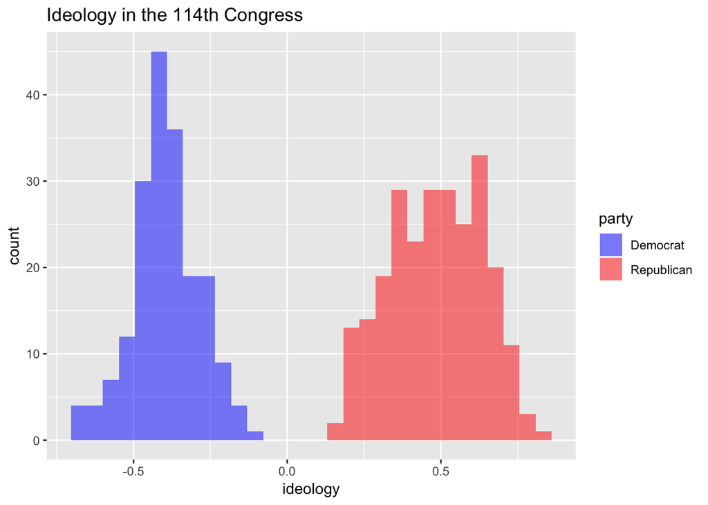

```r
# create a df with only the 114th congress
nominate114_df <- filter(nominate_df, congress == 114)

# a histogram of the 114th congress
ggplot(nominate114_df, aes(x = ideology, fill = party)) +
  geom_histogram(alpha = 0.5, position = "identity") +
  scale_fill_manual(values = c("blue", "red")) +
  labs(title = "Ideology in the 114th Congress")
```

```r
# 5 most conservative members from 114th congress
top_n(nominate114_df, 5, ideology)
```

| congress | chamber | state | district | party | name | ideology |
| --- | --- | --- | --- | --- | --- | --- |
| 114 | House | AL | 6 | Republican | PALMER, Gary James | 0.779 |
| 114 | House | CA | 4 | Republican | McCLINTOCK, Tom | 0.750 |
| 114 | House | CO | 4 | Republican | BUCK, Kenneth Robert | 0.759 |
| 114 | House | OH | 8 | Republican | DAVIDSON, Warren | 0.777 |
| 114 | House | SC | 5 | Republican | MULVANEY, Mick | 0.750 |
| 114 | House | VA | 7 | Republican | BRAT, David A. | 0.825 |

```r
# 5 most liberal members from 114th congress
top_n(nominate114_df, 5, -ideology)
```

| congress | chamber | state | district | party | name | ideology |
| --- | --- | --- | --- | --- | --- | --- |
| 114 | House | CA | 43 | Democrat | WATERS, Maxine | -0.655 |
| 114 | House | CA | 13 | Democrat | LEE, Barbara | -0.687 |
| 114 | House | MI | 13 | Democrat | CONYERS, John, Jr. | -0.658 |
| 114 | House | NJ | 12 | Democrat | WATSON COLEMAN, Bonnie | -0.650 |
| 114 | House | WA | 7 | Democrat | McDERMOTT, James A. | -0.666 |